# Lab 1 — La distribución del ingreso en Colombia

Una foto antes y después de la pandemia (GEIH–DANE, 2019 vs 2021)

Autor/a

Economía del Desarrollo (06230) · Universidad ICESI

Fecha de publicación

20 de agosto de 2026

## 1 De qué se trata

Vamos a usar las encuestas de hogares de Colombia (**GEIH–DANE**) de [**2019**](https://microdatos.dane.gov.co/index.php/catalog/684) y [**2021**](https://microdatos.dane.gov.co/index.php/catalog/733) para mirar, con datos reales, dos cosas que vimos en las lecturas:

1. **La distribución del ingreso** —no solo el promedio—, en la línea de **Sala-i-Martin (2006)**: el promedio esconde quién gana qué.
2. **Quién es pobre** (edad, género, nivel educativo), replicando el perfil del pobre del **Banco Mundial (2020)**, *Poverty and Shared Prosperity*.

La pregunta de fondo: **¿cómo cambió la distribución del ingreso colombiano entre 2019 (antes) y 2021 (después) del choque de la pandemia?**

**AdvertenciaEsto es descriptivo, no causal**

Es una **foto** antes/después. Entre 2019 y 2021 cambió la pandemia, pero también muchas otras cosas (precios, política social, migración…). No hay grupo de comparación ni contrafactual, así que **no podemos atribuir los cambios a la pandemia**. Esa frontera —de la descripción a la causalidad— es el hilo de la Unidad 1.

## 2 Preparación

`pacman` es un gestor de paquetes para R. Su función `p_load()` hace tres cosas en una sola llamada: revisa qué paquetes ya están instalados, instala los que falten y los carga en la sesión. Lo usamos para que el lab arranque igual en cualquier computador, sin que nadie tenga que ir corriendo `install.packages()` paquete por paquete.

```r
if (!require("pacman")) install.packages("pacman")
pacman::p_load(tidyverse, scales, data.table, R.utils)
```

`data.table` es un paquete de R pensado para tablas grandes: hace las mismas operaciones que un `data.frame` pero mucho más rápido y con menos memoria. Aquí lo usamos por una sola de sus funciones, `fread()`. La elegimos porque lee los archivos del DANE en una fracción de lo que tarda `read.csv()`, y sobre todo porque deja fijar a mano el separador y el símbolo decimal —que no son los mismos en 2019 que en 2021—. (`R.utils` es lo que le permite abrir los `.csv.gz` sin descomprimirlos antes.)

```r
rutas_crudos <- c(
  hogares_2019  = "datos/_crudos/geih-2019-hogares.csv.gz",
  personas_2019 = "datos/_crudos/geih-2019-personas.csv.gz",
  hogares_2021  = "datos/_crudos/geih-2021-hogares.csv.gz",
  personas_2021 = "datos/_crudos/geih-2021-personas.csv.gz"
)

hay_crudos <- all(file.exists(rutas_crudos))
hay_crudos
```

```
[1] TRUE
```

## 3 Una transformación del microdato

Los microdatos son públicos y se bajan del portal del DANE, una ficha por año ([2019, cat. 684](https://microdatos.dane.gov.co/index.php/catalog/684) · [2021, cat. 733](https://microdatos.dane.gov.co/index.php/catalog/733)). Ahí el DANE reparte la medición de pobreza en **dos archivos por año**:

| Archivo | Unidad | Qué trae |
| --- | --- | --- |
| **Hogares** | hogar | el ingreso, las líneas de pobreza y los indicadores |
| **Personas** | persona | la demografía: edad, sexo, educación |

Se unen por `directorio` + `secuencia_p`. Por eso son **cuatro** archivos y no dos: sin el de personas no hay edad ni educación; sin el de hogares no hay ingreso ni pobreza.

### 3.1 Leer los archivos crudos

**AdvertenciaLos dos años no vienen en el mismo formato**

**2019** usa separador `;` y decimal `,` (formato europeo). **2021** usa separador `,` y decimal `.`. Por eso los leemos en bloques separados.

```r
hogares_2019 <- fread(
  rutas_crudos[["hogares_2019"]], sep = ";", dec = ",", encoding = "UTF-8",
  select = c("directorio", "secuencia_p", "ingpcug", "lp", "pobre", "indigente")
) |>
  as_tibble() |>
  rename_with(tolower)   # los encabezados del DANE no siempre vienen igual

personas_2019 <- fread(
  rutas_crudos[["personas_2019"]], sep = ";", dec = ",", encoding = "UTF-8",
  select = c("directorio", "secuencia_p", "clase", "p6020", "p6040", "p6210", "fex_c")
) |>
  as_tibble() |>
  rename_with(tolower)
```

```r
hogares_2021 <- fread(
  rutas_crudos[["hogares_2021"]], sep = ",", dec = ".", encoding = "UTF-8",
  select = c("directorio", "secuencia_p", "ingpcug", "lp", "pobre", "indigente")
) |>
  as_tibble() |>
  rename_with(tolower)

personas_2021 <- fread(
  rutas_crudos[["personas_2021"]], sep = ",", dec = ".", encoding = "UTF-8",
  select = c("directorio", "secuencia_p", "clase", "p6020", "p6040", "p6210", "fex_c")
) |>
  as_tibble() |>
  rename_with(tolower)
```

### 3.2 Mirar el dato crudo antes de tocarlo

```r
glimpse(personas_2019)
```

```
Rows: 756,063
Columns: 7
$ directorio  <int> 4804535, 4804535, 4804535, 4804536, 4804536, 4804537, 4804…
$ secuencia_p <int> 1, 1, 1, 1, 1, 1, 1, 1, 1, 1, 1, 1, 1, 1, 1, 1, 1, 1, 1, 1…
$ clase       <int> 1, 1, 1, 1, 1, 1, 1, 1, 1, 1, 1, 1, 1, 1, 1, 1, 1, 1, 1, 1…
$ p6020       <int> 2, 1, 2, 2, 2, 1, 1, 2, 2, 2, 2, 2, 1, 2, 2, 1, 2, 2, 2, 1…
$ p6040       <int> 70, 38, 23, 21, 4, 13, 62, 24, 58, 25, 5, 24, 16, 45, 62, …
$ p6210       <int> 3, 3, 5, 5, 2, 4, 3, 6, 3, 6, 2, 5, 4, 3, 3, 6, 3, 6, 6, 3…
$ fex_c       <dbl> 77.55219, 77.55219, 77.55219, 91.43426, 91.43426, 68.94146…
```

Acá está el problema de frente: los nombres **no dicen nada** (`p6020`, `p6210`, `fex_c`) y las respuestas son **códigos numéricos**. Sin el diccionario del DANE, esto no se puede leer.

El archivo de hogares es más corto, pero es donde vive el ingreso:

```r
glimpse(hogares_2019)
```

```
Rows: 231,831
Columns: 6
$ directorio  <int> 4804535, 4804536, 4804537, 4804538, 4804539, 4804540, 4804…
$ secuencia_p <int> 1, 1, 1, 1, 1, 1, 1, 1, 1, 1, 1, 1, 1, 1, 1, 1, 1, 1, 1, 1…
$ ingpcug     <dbl> 726383.6, 2344105.5, 582307.3, 170000.0, 544105.5, 1858333…
$ lp          <dbl> 403378.1, 403378.1, 403378.1, 403378.1, 403378.1, 403378.1…
$ pobre       <int> 0, 0, 0, 1, 0, 0, 0, 0, 0, 0, 1, 0, 0, 0, 0, 0, 0, 0, 1, 1…
$ indigente   <int> 0, 0, 0, 0, 0, 0, 0, 0, 0, 0, 0, 0, 0, 0, 0, 0, 0, 0, 0, 1…
```

Y así se ven los códigos de educación en el dato, antes de que los toquemos:

```r
personas_2019 |> count(p6210)
```

| p6210 | n |
| --- | --- |
| 1 | 39442 |
| 2 | 20888 |
| 3 | 183534 |
| 4 | 131217 |
| 5 | 171812 |
| 6 | 178635 |
| 9 | 68 |
| NA | 30467 |

**Siete categorías** —de `1` Ninguno a `6` Superior, más el `9` de “no sabe, no informa”— y una fila que el diccionario no anuncia: **`NA`, con 30.467 personas**.

Vale la pena mirar quiénes son, porque no es lo mismo un dato perdido que un dato que nunca se preguntó:

```r
personas_2019 |>
  filter(is.na(p6210)) |>
  count(p6040)
```

| p6040 | n |
| --- | --- |
| 0 | 9621 |
| 1 | 10100 |
| 2 | 10746 |

Son **niños de 0, 1 y 2 años**: al DANE no le pregunta el nivel educativo a menores de tres. No es un problema de calidad del dato, es el diseño del cuestionario. Y el `9` —el verdadero “no informa”— son apenas 68 personas.

Guarde esta tabla: más abajo colapsamos las siete categorías a cuatro, y conviene tener presente cuánta gente hay en cada una antes de agruparlas.

### 3.3 Qué significa cada variable

Estas definiciones están tomadas **textualmente** del diccionario de datos oficial del DANE, que se encuentra en `datos/diccionario-dane/`. No están escritas de memoria.

#### 3.3.1 Las que vienen del archivo de **hogares**

| Variable | Definición del DANE | Códigos |
| --- | --- | --- |
| `directorio` | Llave vivienda | — |
| `secuencia_p` | Llave hogar | — |
| `ingpcug` | Ingreso per cápita de la unidad de gasto **con imputación de arriendo a propietarios y usufructuarios** | pesos corrientes/mes |
| `lp` | Línea de pobreza: *“valor de la canasta básica de bienes que establece el límite de ingresos por debajo del cual un hogar es considerado en pobreza”* | pesos/mes |
| `pobre` | Pobre=1 No pobre=0 | `0` No pobre · `1` Pobre |
| `indigente` | Indigente=1 No indigente=0 | `0` No indigente · `1` Indigente |

#### 3.3.2 Las que vienen del archivo de **personas**

| Variable | Definición del DANE | Códigos |
| --- | --- | --- |
| `clase` | 1. Cabecera, 2. Resto (centros poblados y área rural dispersa) | `1` Cabecera · `2` Resto |
| `p6020` | Sexo | `1` Hombre · `2` Mujer |
| `p6040` | ¿Cuántos años cumplidos tiene? | años |
| `p6210` | ¿Cuál es el nivel educativo más alto alcanzado…? | `1` Ninguno · `2` Preescolar · `3` Básica primaria · `4` Básica secundaria · `5` Media · `6` Superior · `9` No sabe/no informa |
| `fex_c` | **Factor de expansión anualizado** | — |

**ImportanteFactores de expansión**

Cada fila **representa a `fex_c` personas del país**. Una encuesta no es un censo: sin ponderar, todas las cifras están mal. Por eso **toda cifra nacional de este lab va ponderada por `fex`**.

Y ojo con `ingpcug`: no es el salario. Es el ingreso del hogar por persona, e **incluye un arriendo imputado** a quienes viven en vivienda propia. Sin esa imputación, un propietario sin ingresos monetarios parecería más pobre de lo que es.

### 3.4 Unir personas con su hogar

`left_join` **desde personas**: queremos una fila por persona, y a cada una le pegamos el ingreso y la pobreza del hogar al que pertenece. Varias personas comparten hogar, así que el ingreso del hogar se repite en todas sus filas.

```r
geih_2019 <- personas_2019 |>
  left_join(hogares_2019, by = c("directorio", "secuencia_p")) |>
  mutate(anio = 2019)

geih_2021 <- personas_2021 |>
  left_join(hogares_2021, by = c("directorio", "secuencia_p")) |>
  mutate(anio = 2021)

geih_crudo <- bind_rows(geih_2019, geih_2021)
```

### 3.5 Recodificar: de códigos a etiquetas

De las diez variables que sobreviven, **solo tres se recodifican**. El resto se deja como viene o apenas se renombra.

```r
geih_crudo <- geih_crudo |>
  mutate(
    # Sexo: 1 = Hombre, 2 = Mujer.
    sexo = factor(p6020, levels = c(1, 2), labels = c("Hombre", "Mujer")),

    # Clase: 1 = Cabecera (urbano), 2 = Resto (centros poblados y rural disperso).
    area = factor(clase, levels = c(1, 2), labels = c("Urbano", "Rural")),

    # Educación: las SIETE categorías del DANE se colapsan a cuatro.
    educ = case_when(
      p6210 %in% c(1, 2) ~ "Sin educación",
      p6210 == 3         ~ "Primaria",
      p6210 %in% c(4, 5) ~ "Secundaria",
      p6210 == 6         ~ "Superior",
      .default = NA_character_
    ),
    educ = factor(educ, levels = c("Sin educación", "Primaria", "Secundaria", "Superior"))
  )
```

**ImportanteLa recodificación de `educ` es una decisión, no un hecho**

Siete categorías del DANE se vuelven cuatro:

| `p6210` | Etiqueta del DANE | → `educ` |
| --- | --- | --- |
| 1 | Ninguno | Sin educación |
| 2 | Preescolar | Sin educación |
| 3 | Básica primaria (1º–5º) | Primaria |
| 4 | Básica secundaria (6º–9º) | Secundaria |
| 5 | Media (10º–13º) | Secundaria |
| 6 | Superior o universitaria | Superior |
| 9 | No sabe, no informa | `NA` |

Juntar *Ninguno* con *Preescolar* es defendible si lo que interesa es “no alcanzó primaria”. Pero juntar *Básica secundaria* con *Media* **borra la diferencia entre haber llegado a noveno y haberse graduado de bachillerato**, que en el mercado laboral colombiano no es menor. Y mandar el `9` a `NA` supone que quien no informa se parece al promedio de los que sí informaron.

Esas tres decisiones las tomó alguien —nosotros— y hay que poder defenderlas.

### 3.6 Quedarnos con lo que usamos

`directorio` y `secuencia_p` ya cumplieron su función —unir los archivos— y se van.

```r
geih <- geih_crudo |>
  select(
    anio,
    fex = fex_c,        # factor de expansión anualizado
    ingpcug,            # ingreso per cápita de la unidad de gasto
    lp,                 # línea de pobreza
    pobre,              # 1 = persona en pobreza monetaria
    indigente,          # 1 = persona en pobreza extrema
    edad = p6040,
    sexo, educ, area
  ) |>
  filter(!is.na(ingpcug), !is.na(fex))   # sin ingreso o sin peso, la fila no sirve

nrow(geih_crudo) - nrow(geih)   # cuántas filas se fueron en el filtro
```

```
[1] 0
```

Da **cero**: en estos dos años el módulo de pobreza del DANE viene completo, sin ingresos ni pesos faltantes. El filtro no sobra —es la red de seguridad que uno pone sin saber qué va a encontrar—, pero conviene saber que acá no quitó nada. Si en otro año quitara muchas filas, esa sería una noticia que habría que investigar antes de seguir.

**Resumen de lo que pasó con cada variable:**

| Qué se hizo | Variables |
| --- | --- |
| **Sin cambios** | `ingpcug`, `lp`, `pobre`, `indigente` |
| **Solo renombradas** | `fex_c` → `fex`, `p6040` → `edad` |
| **Recodificadas** | `p6020` → `sexo`, `clase` → `area`, `p6210` → `educ` |
| **Descartadas** | `directorio`, `secuencia_p` (solo servían para unir) |
| **Agregada** | `anio`, al apilar los dos años |

### 3.7 Verificación: ¿reproducimos las cifras oficiales?

Este es el control de calidad. Si la limpieza se rompió en algún punto, acá se nota.

```r
geih |>
  group_by(anio) |>
  summarise(
    pobreza  = round(weighted.mean(pobre, fex) * 100, 1),
    extrema  = round(weighted.mean(indigente, fex) * 100, 1),
    personas_millones = round(sum(fex) / 1e6, 1)
  )
```

| anio | pobreza | extrema | personas_millones |
| --- | --- | --- | --- |
| 2019 | 35.7 | 9.6 | 48.9 |
| 2021 | 39.3 | 12.2 | 49.9 |

Las cifras oficiales del DANE son **35,7 %** y **39,3 %** de pobreza monetaria, y **9,6 %** y **12,2 %** de pobreza extrema. Si la tabla de arriba coincide, la limpieza está bien hecha.

```r
# Sin los archivos crudos, arrancamos del subset ya construido.
geih <- read_rds("datos/geih_pobreza_2019_2021.rds") |> as_tibble()
```

```r
geih <- geih |> mutate(anio = factor(anio))   # el año es etiqueta, no número
```

## 4 Una mirada a los datos

```r
dim(geih)        # filas (personas) x columnas
```

```
[1] 1467444      10
```

```r
head(geih)       # primeras filas
```

| anio | fex | ingpcug | lp | pobre | indigente | edad | sexo | educ | area |
| --- | --- | --- | --- | --- | --- | --- | --- | --- | --- |
| 2019 | 77.55219 | 726383.6 | 403378.1 | 0 | 0 | 70 | Mujer | Primaria | Urbano |
| 2019 | 77.55219 | 726383.6 | 403378.1 | 0 | 0 | 38 | Hombre | Primaria | Urbano |
| 2019 | 77.55219 | 726383.6 | 403378.1 | 0 | 0 | 23 | Mujer | Secundaria | Urbano |
| 2019 | 91.43426 | 2344105.5 | 403378.1 | 0 | 0 | 21 | Mujer | Secundaria | Urbano |
| 2019 | 91.43426 | 2344105.5 | 403378.1 | 0 | 0 | 4 | Mujer | Sin educación | Urbano |
| 2019 | 68.94146 | 582307.3 | 403378.1 | 0 | 0 | 13 | Hombre | Secundaria | Urbano |

```r
glimpse(geih)    # tipo de cada variable
```

```
Rows: 1,467,444
Columns: 10
$ anio      <fct> 2019, 2019, 2019, 2019, 2019, 2019, 2019, 2019, 2019, 2019, …
$ fex       <dbl> 77.55219, 77.55219, 77.55219, 91.43426, 91.43426, 68.94146, …
$ ingpcug   <dbl> 726383.6, 726383.6, 726383.6, 2344105.5, 2344105.5, 582307.3…
$ lp        <dbl> 403378.1, 403378.1, 403378.1, 403378.1, 403378.1, 403378.1, …
$ pobre     <int> 0, 0, 0, 0, 0, 0, 0, 0, 0, 0, 1, 1, 1, 1, 0, 0, 0, 0, 0, 0, …
$ indigente <int> 0, 0, 0, 0, 0, 0, 0, 0, 0, 0, 0, 0, 0, 0, 0, 0, 0, 0, 0, 0, …
$ edad      <int> 70, 38, 23, 21, 4, 13, 62, 24, 58, 25, 5, 24, 16, 45, 62, 23…
$ sexo      <fct> Mujer, Hombre, Mujer, Mujer, Mujer, Hombre, Hombre, Mujer, M…
$ educ      <fct> Primaria, Primaria, Secundaria, Secundaria, Sin educación, S…
$ area      <fct> Urbano, Urbano, Urbano, Urbano, Urbano, Urbano, Urbano, Urba…
```

¿A cuántos colombianos representa cada año?

```r
geih |>
  group_by(anio) |>
  summarise(personas_millones = round(sum(fex) / 1e6, 1))
```

| anio | personas_millones |
| --- | --- |
| 2019 | 48.9 |
| 2021 | 49.9 |

## 5 Ingreso por quintil

> **Lección de Sala-i-Martin:** mirar la *distribución*, no solo la media.

Un **quintil ponderado** parte a la población en 5 grupos de igual tamaño (20 % cada uno). Lo armamos en tres pasos que se pueden leer de corrido:

1. ordenamos a las personas de la más pobre a la más rica,
2. acumulamos su peso poblacional,
3. cortamos ese acumulado en 20 %, 40 %, 60 % y 80 %.

```r
geih <- geih |>
  group_by(anio) |>                       # los quintiles se arman DENTRO de cada año
  arrange(ingpcug, .by_group = TRUE) |>
  mutate(
    poblacion_acumulada = cumsum(fex) / sum(fex),
    quintil = cut(
      poblacion_acumulada,
      breaks = c(-Inf, 0.2, 0.4, 0.6, 0.8, Inf),
      labels = c("Q1", "Q2", "Q3", "Q4", "Q5")
    )
  ) |>
  ungroup()
```

Revisión rápida: los cinco grupos deben pesar ~20 % de la población cada uno.

```r
geih |>
  group_by(anio, quintil) |>
  summarise(personas = sum(fex), .groups = "drop") |>
  group_by(anio) |>
  mutate(peso_pct = round(personas / sum(personas) * 100, 1)) |>
  ungroup()
```

| anio | quintil | personas | peso_pct |
| --- | --- | --- | --- |
| 2019 | Q1 | 9782160 | 20 |
| 2019 | Q2 | 9781968 | 20 |
| 2019 | Q3 | 9782173 | 20 |
| 2019 | Q4 | 9782329 | 20 |
| 2019 | Q5 | 9782305 | 20 |
| 2021 | Q1 | 9988750 | 20 |
| 2021 | Q2 | 9988642 | 20 |
| 2021 | Q3 | 9989049 | 20 |
| 2021 | Q4 | 9988889 | 20 |
| 2021 | Q5 | 9988848 | 20 |

**NotaOjo con los pesos corrientes**

El ingreso está en pesos **corrientes** de cada año (sin descontar inflación), así que la comparación de *niveles* 2019 vs 2021 mezcla algo de inflación. La razón Q5/Q1 y las participaciones sí son comparables: son cocientes.

```r
quintiles <- geih |>
  group_by(anio, quintil) |>
  summarise(
    ingreso_medio = weighted.mean(ingpcug, fex),
    ingreso_total = sum(ingpcug * fex),
    .groups = "drop"
  ) |>
  group_by(anio) |>
  mutate(participacion = ingreso_total / sum(ingreso_total)) |>
  ungroup()

quintiles
```

| anio | quintil | ingreso_medio | ingreso_total | participacion |
| --- | --- | --- | --- | --- |
| 2019 | Q1 | 120780.3 | 1.181492e+12 | 0.0342622 |
| 2019 | Q2 | 266057.9 | 2.602570e+12 | 0.0754722 |
| 2019 | Q3 | 429776.1 | 4.204144e+12 | 0.1219165 |
| 2019 | Q4 | 695643.8 | 6.805017e+12 | 0.1973395 |
| 2019 | Q5 | 2012877.3 | 1.969058e+13 | 0.5710095 |
| 2021 | Q1 | 125689.0 | 1.255476e+12 | 0.0355819 |
| 2021 | Q2 | 269133.7 | 2.688280e+12 | 0.0761895 |
| 2021 | Q3 | 425657.7 | 4.251915e+12 | 0.1205050 |
| 2021 | Q4 | 697268.6 | 6.964938e+12 | 0.1973958 |
| 2021 | Q5 | 2014599.2 | 2.012352e+13 | 0.5703279 |

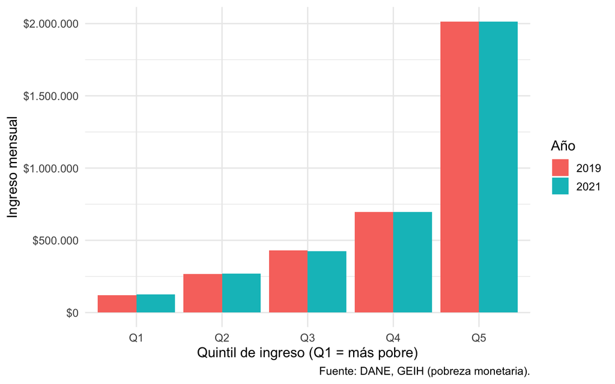

Figura 1: Ingreso per cápita promedio por quintil, 2019 vs 2021.

```r
ggplot(quintiles, aes(quintil, ingreso_medio, fill = anio)) +
  geom_col(position = "dodge") +
  scale_y_continuous(labels = label_dollar(prefix = "$", big.mark = ".", decimal.mark = ",")) +
  labs(x = "Quintil de ingreso (Q1 = más pobre)", y = "Ingreso mensual",
       fill = "Año", caption = "Fuente: DANE, GEIH (pobreza monetaria).") +
  theme_minimal(base_size = 13)
```

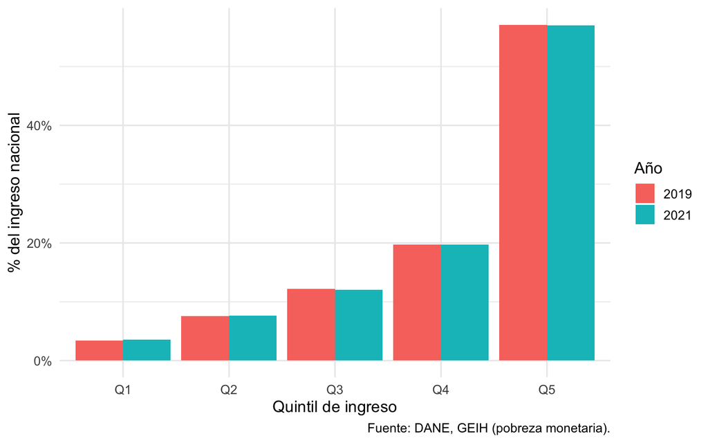

Figura 2: Participación en el ingreso total por quintil. El Q5 concentra la mayor parte.

```r
ggplot(quintiles, aes(quintil, participacion, fill = anio)) +
  geom_col(position = "dodge") +
  scale_y_continuous(labels = label_percent()) +
  labs(x = "Quintil de ingreso", y = "% del ingreso nacional",
       fill = "Año", caption = "Fuente: DANE, GEIH (pobreza monetaria).") +
  theme_minimal(base_size = 13)
```

La **razón Q5/Q1** es una medida simple de desigualdad: ¿cuántas veces gana el quintil más rico frente al más pobre? Pasamos los quintiles de filas a columnas para poder dividir Q5 entre Q1.

```r
brecha <- quintiles |>
  select(anio, quintil, ingreso_medio) |>
  pivot_wider(names_from = quintil, values_from = ingreso_medio) |>
  mutate(brecha_Q5_Q1 = round(Q5 / Q1, 1)) |>
  select(anio, brecha_Q5_Q1)

brecha
```

| anio | brecha_Q5_Q1 |
| --- | --- |
| 2019 | 16.7 |
| 2021 | 16.0 |

## 6 Pobreza 2019 vs 2021

Una persona es **pobre** si el ingreso per cápita de su hogar cae bajo la **línea de pobreza** oficial del DANE (específica de cada año). Como `pobre` e `indigente` son variables 0/1, su promedio ponderado **es** la tasa de pobreza.

```r
pobreza <- geih |>
  group_by(anio) |>
  summarise(
    pobreza_pct         = round(weighted.mean(pobre, fex) * 100, 1),
    pobreza_extrema_pct = round(weighted.mean(indigente, fex) * 100, 1)
  )

pobreza
```

| anio | pobreza_pct | pobreza_extrema_pct |
| --- | --- | --- |
| 2019 | 35.7 | 9.6 |
| 2021 | 39.3 | 12.2 |

Para graficar los dos indicadores juntos los pasamos a **formato largo**: una fila por año y por indicador.

```r
pobreza_larga <- pobreza |>
  pivot_longer(
    cols = c(pobreza_pct, pobreza_extrema_pct),
    names_to = "indicador",
    values_to = "pct"
  ) |>
  mutate(indicador = factor(
    indicador,
    levels = c("pobreza_pct", "pobreza_extrema_pct"),
    labels = c("Pobreza monetaria", "Pobreza extrema")
  ))

pobreza_larga
```

| anio | indicador | pct |
| --- | --- | --- |
| 2019 | Pobreza monetaria | 35.7 |
| 2019 | Pobreza extrema | 9.6 |
| 2021 | Pobreza monetaria | 39.3 |
| 2021 | Pobreza extrema | 12.2 |

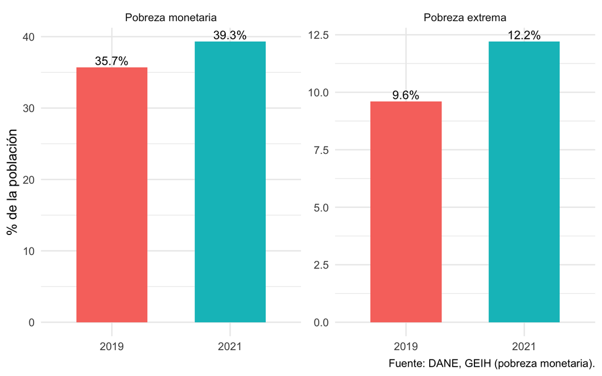

Figura 3: Tasa de pobreza monetaria y extrema, antes/después de la pandemia.

```r
ggplot(pobreza_larga, aes(anio, pct, fill = anio)) +
  geom_col(width = 0.6) +
  geom_text(aes(label = paste0(pct, "%")), vjust = -0.3, size = 4) +
  facet_wrap(~ indicador, scales = "free_y") +
  labs(x = NULL, y = "% de la población",
       caption = "Fuente: DANE, GEIH (pobreza monetaria).") +
  theme_minimal(base_size = 13) +
  theme(legend.position = "none")
```

La pobreza monetaria pasó de **35,7 %** a **39,3 %**, y la extrema de **9,6 %** a **12,2 %**: la foto de 2021 muestra más personas bajo la línea.

## 7 ¿Quién es pobre? El perfil del pobre

> **Lección del Banco Mundial (Figura O.5):** el pobre tiene un rostro —es joven y de baja escolaridad—. Veámoslo en Colombia.

Mostramos la **composición** de la población pobre: de cada 100 pobres, ¿cuántos hay en cada grupo? Es distinto de la **tasa** de pobreza (eso lo vemos al final).

```r
# Grupos de edad estilo Banco Mundial.
geih <- geih |>
  mutate(grupo_edad = cut(
    edad,
    breaks = c(-Inf, 14, 24, 34, 44, 54, 64, Inf),
    labels = c("0-14", "15-24", "25-34", "35-44", "45-54", "55-64", "65+")
  ))

# Nos quedamos solo con las personas pobres: el resto de la sección es sobre ellas.
pobres <- geih |> filter(pobre == 1)
```

### 7.1 Perfil por edad

`count(wt = fex)` suma los factores de expansión: cuenta **personas del país**, no filas de la encuesta.

```r
perfil_edad <- pobres |>
  filter(!is.na(grupo_edad)) |>
  count(anio, grupo_edad, wt = fex, name = "personas") |>
  group_by(anio) |>
  mutate(pct = personas / sum(personas) * 100) |>
  ungroup()

perfil_edad
```

| anio | grupo_edad | personas | pct |
| --- | --- | --- | --- |
| 2019 | 0-14 | 6300314 | 36.063530 |
| 2019 | 15-24 | 3104790 | 17.772083 |
| 2019 | 25-34 | 2497216 | 14.294275 |
| 2019 | 35-44 | 2046037 | 11.711689 |
| 2019 | 45-54 | 1468365 | 8.405046 |
| 2019 | 55-64 | 1000565 | 5.727318 |
| 2019 | 65+ | 1052755 | 6.026059 |
| 2021 | 0-14 | 6834839 | 34.833719 |
| 2021 | 15-24 | 3490720 | 17.790438 |
| 2021 | 25-34 | 2928845 | 14.926842 |
| 2021 | 35-44 | 2417075 | 12.318611 |
| 2021 | 45-54 | 1654844 | 8.433904 |
| 2021 | 55-64 | 1160687 | 5.915434 |
| 2021 | 65+ | 1134319 | 5.781052 |

### 7.2 Perfil por sexo

El mismo patrón de cuatro pasos, cambiando la variable de agrupación.

```r
perfil_sexo <- pobres |>
  filter(!is.na(sexo)) |>
  count(anio, sexo, wt = fex, name = "personas") |>
  group_by(anio) |>
  mutate(pct = personas / sum(personas) * 100) |>
  ungroup()

perfil_sexo
```

| anio | sexo | personas | pct |
| --- | --- | --- | --- |
| 2019 | Hombre | 8429845 | 48.25315 |
| 2019 | Mujer | 9040197 | 51.74685 |
| 2021 | Hombre | 9425571 | 48.03737 |
| 2021 | Mujer | 10195760 | 51.96263 |

### 7.3 Perfil por nivel educativo

Acá filtramos a **15+ años**: la educación de un niño de 6 años no dice nada.

```r
perfil_educ <- pobres |>
  filter(edad >= 15, !is.na(educ)) |>
  count(anio, educ, wt = fex, name = "personas") |>
  group_by(anio) |>
  mutate(pct = personas / sum(personas) * 100) |>
  ungroup()

perfil_educ
```

| anio | educ | personas | pct |
| --- | --- | --- | --- |
| 2019 | Sin educación | 906466.4 | 8.116191 |
| 2019 | Primaria | 3345394.4 | 29.953523 |
| 2019 | Secundaria | 5747854.2 | 51.464330 |
| 2019 | Superior | 1168902.5 | 10.465955 |
| 2021 | Sin educación | 811496.4 | 6.347192 |
| 2021 | Primaria | 3314612.3 | 25.925536 |
| 2021 | Secundaria | 7106096.4 | 55.580967 |
| 2021 | Superior | 1552920.4 | 12.146306 |

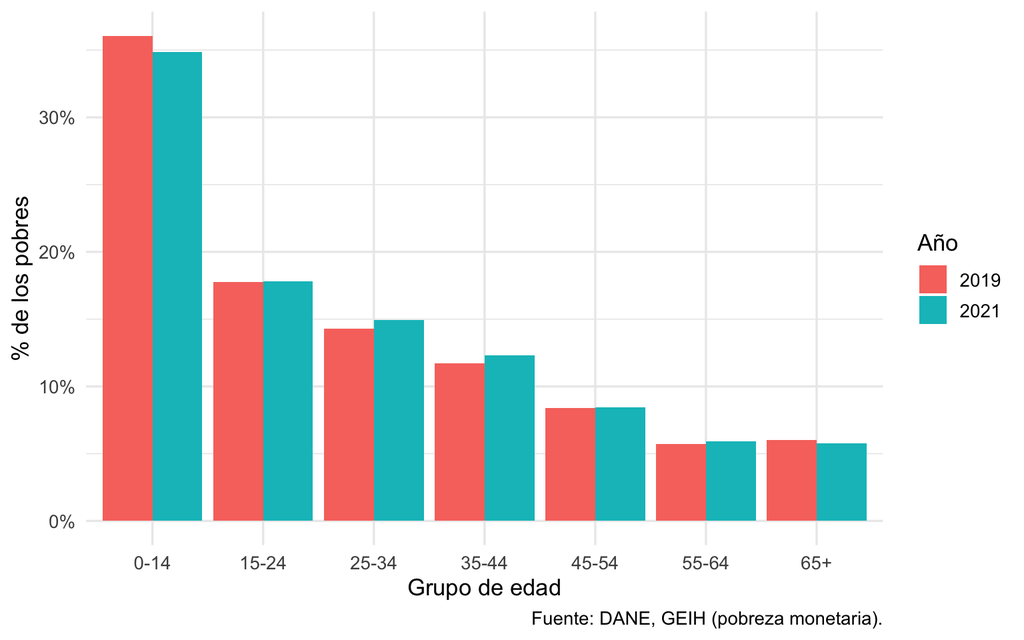

Figura 4: Composición de los pobres por grupo de edad.

```r
ggplot(perfil_edad, aes(grupo_edad, pct, fill = anio)) +
  geom_col(position = "dodge") +
  scale_y_continuous(labels = label_percent(scale = 1)) +
  labs(x = "Grupo de edad", y = "% de los pobres", fill = "Año",
       caption = "Fuente: DANE, GEIH (pobreza monetaria).") +
  theme_minimal(base_size = 13)
```

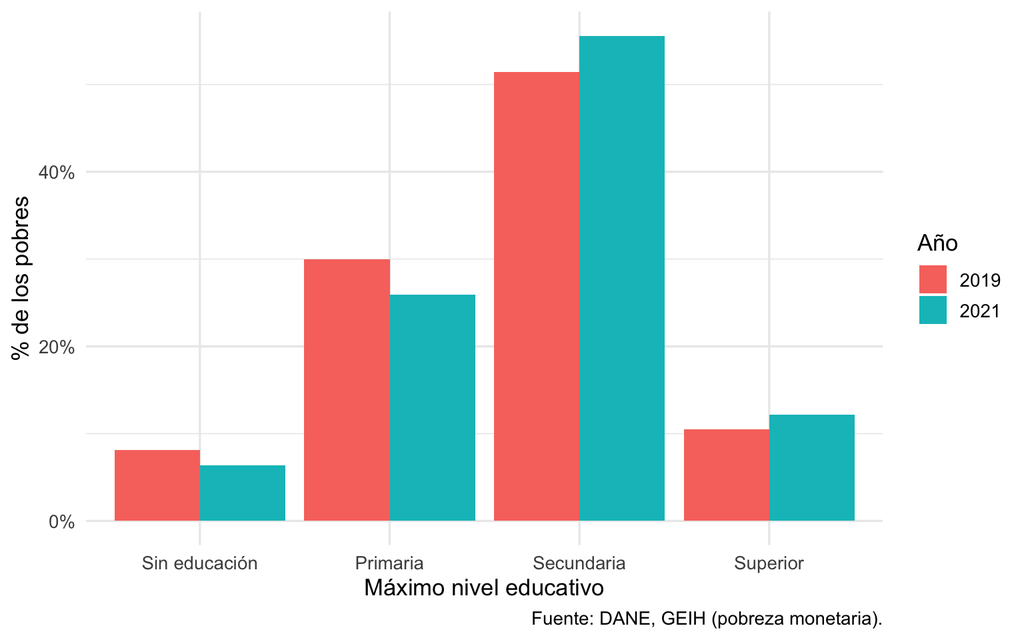

Figura 5: Composición de los pobres por nivel educativo (15+ años).

```r
ggplot(perfil_educ, aes(educ, pct, fill = anio)) +
  geom_col(position = "dodge") +
  scale_y_continuous(labels = label_percent(scale = 1)) +
  labs(x = "Máximo nivel educativo", y = "% de los pobres", fill = "Año",
       caption = "Fuente: DANE, GEIH (pobreza monetaria).") +
  theme_minimal(base_size = 13)
```

Como complemento, la **tasa** de pobreza por nivel educativo. La composición dice cuántos pobres hay en cada grupo; la tasa dice qué grupo tiene más **riesgo** de serlo.

```r
tasa_por_educ <- geih |>
  filter(edad >= 15, !is.na(educ)) |>
  group_by(anio, educ) |>
  summarise(tasa_pobreza = round(weighted.mean(pobre, fex) * 100, 1),
            .groups = "drop") |>
  arrange(educ, anio)

tasa_por_educ
```

| anio | educ | tasa_pobreza |
| --- | --- | --- |
| 2019 | Sin educación | 51.4 |
| 2021 | Sin educación | 48.6 |
| 2019 | Primaria | 39.2 |
| 2021 | Primaria | 39.7 |
| 2019 | Secundaria | 34.0 |
| 2021 | Secundaria | 39.6 |
| 2019 | Superior | 12.6 |
| 2021 | Superior | 16.1 |

## 8 Síntesis y discusión

- La pobreza monetaria **subió de 35,7 % a 39,3 %** entre 2019 y 2021.
- El golpe no fue parejo: revise qué quintil cambió más y cómo se movió la brecha Q5/Q1 (Sección 5).
- El rostro del pobre sigue siendo **joven y de baja escolaridad** (Sección 7), igual que en el informe del Banco Mundial.

**NotaPara discutir en clase**

1. ¿Por qué *no* podemos llamar a esto “el efecto de la pandemia”? ¿Qué necesitaríamos —un grupo de comparación, una fuente de variación exógena— para acercarnos a un efecto causal?
2. ¿La desigualdad (brecha Q5/Q1) subió o bajó? ¿Qué le falta a esa medida?
3. Comparando con la Figura O.5 del Banco Mundial, ¿el perfil del pobre colombiano se parece al patrón global?
4. El ingreso está en pesos corrientes. ¿Cómo cambiaría la lectura si lo deflactáramos?

*Datos: DANE — Medición de Pobreza Monetaria y Desigualdad (GEIH), microdatos anonimizados, cat. 684 (2019) y 733 (2021). «Fuente: DANE, www.dane.gov.co».*